# Midterm Project - NPS Data Analysis

## Description of Problem

Make School’s Summer Academy typically lasts for 8 weeks, although this can vary by location. Management wants to make sure that students continue to be satisfied with their experience as the program scales. Every week, students are given a survey asking their satisfaction with the program in the form of a Net Promoter Score (NPS) question, which is a tool commonly used to measure customer loyalty and promotion.

You have been given data from Summer Academy in 2016 (optional) and 2017 (mandatory). Download the data [here](https://drive.google.com/file/d/1IMb2HWKoxkayxWe9j_5x2DkJZriWnNDN/view).

#### You’ve seen NPS before if you’ve been asked a question like:

```
“On a scale of 1 to 10, how likely are you to recommend [X] to a friend or colleague?”
```

- Clean and investigate Make School NPS data to find interesting and actionable trends that help inform decision-makers.
- You should create a data dictionary that describes what each column’s possible values mean.
- Create a presentation in a Jupyter Notebook using data visualizations and other techniques that allow non-technical team members to understand your findings.

### Background on NPS

#### NPS segments all responses between 1 and 10 into three categories based on their sentiment:

- Promoter (9 – 10)
- Passive (7 – 8)
- Detractor (1 – 6)

#### To calculate NPS, companies follow these steps:

1. Segment all responses into Promoter, Passive, and Detractor categories.
2. Calculate the percentage of responses in each category out of the total number of responses to the survey.
3. Subtract the Detractors percentage from the Promoters percentage. This is the NPS.

In other words, NPS can be calculated with this equation:

#### NPS = ( (Promoters - Detractors) / (Promoters + Passives + Detractors) ) * 100

NPS can range from –100 (if everyone is a detractor) to +100 (if everyone is a promoter).

For more detailed information on NPS, [read this article](https://blog.capterra.com/what-is-nps-net-promoter-score-explained/).

## All Are Favorite Friends (Imports)

```python
# Pandas is a library for basic data analysis
import pandas as pd

# NumPy is a library for advanced mathematical computation
import numpy as np

# MatPlotLib is a library for basic data visualization
import matplotlib.pyplot as plt

# SeaBorn is a library for advanced data visualization
import seaborn as sns

# Dataset from above
df = pd.read_csv('Datasets/Student Feedback Surveys-Superview.csv')
```

### Lets Take A Peak At What We're Working With

```python
df.columns
```

```
Index(['ID', 'Location', 'Track', 'Week', 'Rating (Num)', 'Schedule Pacing'], dtype='object')
```

```python
df.tail()
```

|  | ID | Location | Track | Week | Rating (Num) | Schedule Pacing |
| --- | --- | --- | --- | --- | --- | --- |
| 1448 | 1495 | New York City | Apps, Explorer | Week 7 | 10 | Just right |
| 1449 | 1496 | New York City | Apps, Explorer | Week 7 | 8 | Just right |
| 1450 | 1497 | New York City | Apps | Week 7 | 10 | Just right |
| 1451 | 1498 | New York City | Apps, Explorer | Week 7 | 1 | A little too slow |
| 1452 | 1499 | New York City | Apps | Week 5 | 8 | Just right |

```python
"""Create new column as NPS Score
    Promoter (9 – 10)
    Passive (7 – 8)
    Detractor (1 – 6)"""
df['NPS'] = df['Rating (Num)'].map( {'1': 'det', '2': 'det', '3': 'det',
                                     '4': 'det', '5': 'det', '6': 'det',
                                     '7': 'pas', '8': 'pas', '9': 'pro', '10': 'pro'} ).astype(str)
df['NPS'].value_counts()
```

```
pro    760
pas    569
det    119
nan      5
Name: NPS, dtype: int64
```

```python
df.tail()
```

|  | ID | Location | Track | Week | Rating (Num) | Schedule Pacing | NPS |
| --- | --- | --- | --- | --- | --- | --- | --- |
| 1448 | 1495 | New York City | Apps, Explorer | Week 7 | 10 | Just right | pro |
| 1449 | 1496 | New York City | Apps, Explorer | Week 7 | 8 | Just right | pas |
| 1450 | 1497 | New York City | Apps | Week 7 | 10 | Just right | pro |
| 1451 | 1498 | New York City | Apps, Explorer | Week 7 | 1 | A little too slow | det |
| 1452 | 1499 | New York City | Apps | Week 5 | 8 | Just right | pas |

### Questions to Consider Answering

In this scenario, you’ve just been given access to this data from your boss, with the instructions to:

```
“See if you can find anything in here that can help the business.”
– This is a very broad set of instructions.
```

In order to complete this task you should consider finding answers to the following questions:

- How many more promoters are there than detractors across our 2017 data?
- Which track boasts the best promoter-to-detractor ratio?
- Does the student experience get better the longer that they are enrolled at the Summer Academy?
- Does student satisfaction vary by location?
- What are things we could find here that could “help the business”?
- What sorts of information does this dataset contain?
- What kinds of questions might we be able to answer with this data?
- What kinds of questions can’t we answer with this data?
- What sorts of information might be actionable?

### 1. How many more promoters are there than detractors across our 2017 data?

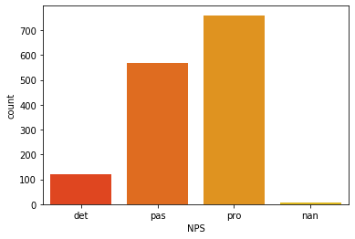

```python
# Well Lets Check
sns.countplot(x='NPS', palette='autumn', data=df)
```

```python
Promoters = len(df[df['NPS']=='pro'])
Passives = len(df[df['NPS']=='pas'])
Detractors = len(df[df['NPS']=='det'])

HMM = Promoters - Detractors
NPS = ( (Promoters - Detractors) / (Promoters + Passives + Detractors) ) * 100

print('Num promoters - Num detractors:', Promoters, '-', Detractors, '=', HMM, 'more promoters than detractors')
print('Overall NPS Score: %.4f' %NPS)
```

```
Num promoters - Num detractors: 760 - 119 = 641 more promoters than detractors
Overall NPS Score: 44.2680
```